# Proyecto final GLM

Andrea Fernandez, Andrea García y Carlos Petricoli

01/11/2014

# Introducción

Dada la situación de inseguridad que ha experimentado el país en los últimos años la Secretaría de Gobernación (SEGOB) desarrolló el Programa Nacional de Prevención Social de la Violencia y la Delincuencia (PNPSVD) en 2013 con el objetivo de atender los factores de riesgo y protección vinculados a la violencia y la delincuencia.

La prevención del delito se refiere, en términos generales, a las acciones enfocadas a disminuir las amenazas, el riesgo y las oportunidades de que el delito ocurra mediante la identificación y eliminación de las causas, elementos de oportunidad y condiciones sociales que permiten que la delincuencia se desarrolle y fortalezca $\footnote{ Prevención del Delito en México: ¿dónde quedo la evidencia?, México Evalúa 2014}$. En la literatura de prevención del delito existen tres enfoques:

1. Prevención por etapas de desarrollo del delito (Brantingham y Faust, 1976; Van Dijk & de Waard, 1991): Esta corriente se encuentra organizada acuerdo al grado de desarrollo (primario, secundario o terciario) del fenómeno delictivo. Es importante determinar qué etapa es prioritaria de acuerdo al contexto y a los objetivos definidos e identificar cuáles son las condiciones locales que requieren de un mayor énfasis de acuerdo a las metas establecidas para el corto y el largo plazo.
2. Prevención del delito por estrategia operacional (Clarke, 1980, 1983, 1992, 1995; Cornish & Clarke, 1986; Farrington, 1994 y 1996; Mayhew et al, 1976; Tim Hope, 1995; Skogan, 1990;): Este enfoque considera que la motivación para cometer un delito se encuentra en las circunstancias individuales y se divide en tres estrategias operacionales a) situacional, b) comunitaria, y c) de criminalidad.
3. Prevención por orientación de la estrategia (Hawkins y Weis, 1985; Waller y Weiler, 1985; Newman, 1972; Kaplan et al, 1978; Kushmuk y Wittermore, 1981): Este último se clasifica en dos, de acuerdo a la orientación de la estrategia (a través del desarrollo social) y a través del diseño del entorno. Para una mejor política pública es altamente recomendable combinar el diseño del entorno y los programas de desarrollo social.

Para efectos del Programa (PNPSV), se entiende por factores de riesgo aquellas situaciones de tipo individual, familiar, escolar o social que incrementan las probabilidades de que las personas desarrollen conductas violentas o delictivas $\footnote{ PROGRAMA Nacional para la Prevención Social de la Violencia y la Delincuencia 2014-2018, DOF abril 2014}$. La existencia de estos factores aumenta la probabilidad de que el individuo se vea inmerso en actos de violencia o delincuencia. Es por ello que el PNPSV se concentra en la prevención del delito por estrategia operacional (segunda corriente) enfocándose en las condiciones socioeconómicas que parecen estar asociadas al desarrollo del delito (primaria $\footnote{ Prevención primaria: acción directa para evitar o revertir condiciones socioeconómicas que parecen estar asociadas al desarrollo del delito, tales como la pobreza, la desigualdad, el crecimiento urbano descontrolado, etcétera. Además, busca modificar las características del espacio físico y las relaciones sociales y comunitarias que podrían generar condiciones criminógenas en el largo plazo.}$) y a los grupos en situación de riesgo delictivo (secundaria $\footnote{ Prevención secundaria: identificación e intervención temprana en los individuos o grupos en situación de riesgo delictivo. Ésta busca identificar el desarrollo potencial de actividades delictivas de individuos o grupos vulnerables en las zonas de alto riesgo e intervenir en su dinámica y calidad de vida de tal forma que no cometan delitos.}$).

Para la primera fase del Programa se eligieron 57 demarcaciones de intervención prioritaria y 43 demarcaciones para un segundo ámbito de intervención. Para la elección de las demarcaciones se presume se utilizaron los factores de riesgo asociados a la violencia y a la delincuencia explicados a continuación.

Pirámide de la Violencia, Factores de riesgo asociados a la violencia y delincuencia

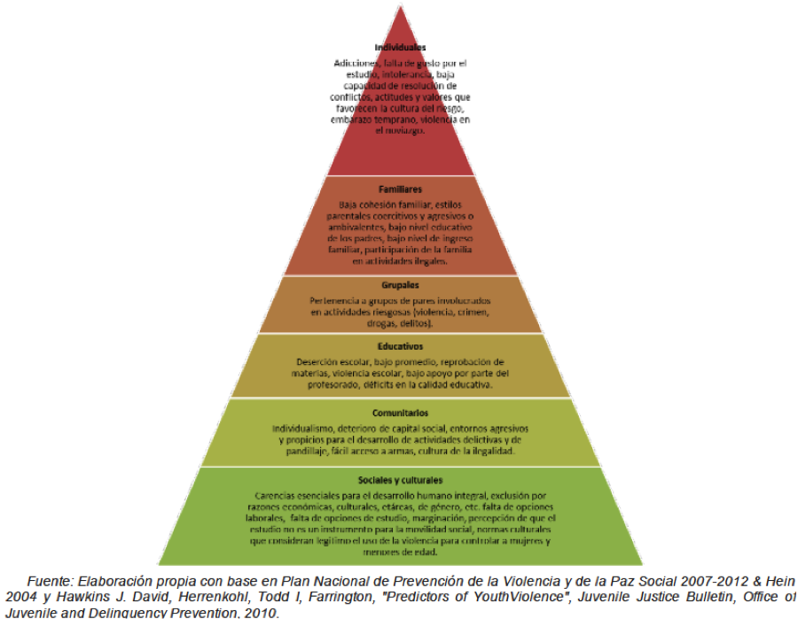

El objetivo de este estudio es caracterizar los municipios del país entorno a los diferentes factores de riesgo que el programa busca atender. Además, se busca generar recomendaciones para identificar las buenas prácticas y poder hacer una gestión más eficiente de los recursos del presupuesto federal.

# Consulta con Expertos

Para complementar el estudio se incluyó la opinión de varios expertos entre los cuales destaca la revisión del PNPSV de México Evalúa y los comentarios de expertos del CIDE y COLMEX.

## México Evalúa

La ONG México Evalúa realizó el estudio “Prevención del Delito en México: ¿Dónde quedo la Evidencia?” para analizar cuatro puntos estratégicos del PNPSVD 1) Metodología de selección de las demarcaciones prioritarias; 2) La distribución de los recursos del programa por demarcación y por eje rector; 3) Los diagnósticos de los proyectos de prevención; y 4) Los indicadores y metas de los mismos.

La primera crítica se enfoca a la falta de transparencia que hubo en la selección de las 57 demarcaciones prioritarias y la falta de otorgamiento de recursos a las 43 demarcaciones clasificadas como parte de un segundo ámbito de intervención. Cabe mencionar que la distribución de recursos no está vinculada a los objetivos del programa, al parecer sólo utilizaron la proporción de la población y la de homicidios como indicador para distribuir los recursos en las demarcaciones prioritarias. Además la mayoría de los diagnósticos en los proyectos de prevención presentados por las autoridades locales carecen de evidencia sólida, de indicadores y metas que hagan posible la evaluación de su impacto en materia de prevención social.

## COLMEX – Dr. Arturo Alvarado

El Dr. Arturo Alvarado realizó una investigación comparativa colectiva sobre la violencia juvenil en diez ciudades de cinco países de América Latina $\footnote{ Las ciudades y países del estudio son Buenos Aires, en Argentina; Sao Paulo, en Brasil; Cali y Medellín, en Colombia; la capital de Guatemala; y las ciudades de Cancún, Xalapa, León, Ciudad Juárez y la Ciudad de México.}$ en el estudio “Violencia y Acceso a la Justicia en América Latina”, ¿Cómo perciben la violencia los jóvenes? donde exploraron las tendencias de la muerte violenta que afectan a la juventud y en entorno urbano para conocer los problemas de violencia personal, interpersonal, colectiva y organizada que afectan a la sociedad. Los factores de riesgo que exploran son los siguientes: • Individuales • Familiares • Comunitarios /Contextuales • Escuela • Laborales • Políticos

Para fines del estudio definen la violencia la como “el uso intencional de la fuerza física o el poder, amenaza o efectivo, contra uno mismo, otra persona o un grupo o comunidad, que cause o tenga muchas probabilidades de causar lesiones, muerte, daños psicológicos, trastornos del desarrollo o privaciones.” $\footnote{ Informe mundial sobre la violencia y la salud, Organización Mundial de la Salud, 2002}$ El problema de la violencia es un problema de desarrollo y de salud pública, se necesita dar a los jóvenes oportunidades de ser ciudadanos plenos.

En el caso de México la multiculturalidad del territorio incluye ciudades de nivel bajo, alto y medio de violencia. Realizaron estudios de campo en Cancún, León, Xalapa, Cd. Juárez entre otras.

En ciudades de niveles bajos de violencia el problema que encontraron se centra en los contrastes de la sociedad, tal como Cancún entre la población local, la temporal y la turística. Donde dos sociedades conviven sin mezclarse e incluso la ley aplica de manera diferenciada. Mientras que en León la sociedad esta mejor cohesionada pero tienen un gran rezago educativo, problemas de adicciones fuertes y desempleo.

Para Xalapa el proceso de crecimiento urbano desorganizado y la alta incidencia de grupos delictivos ha generado un nivel de violencia muy alto mientras que en Cd Juárez el problema radica en la falta de acceso a zonas de recreación y la necesidad de pertenecer a grupos. Esto genera enfrentamientos entre bandas . Además sufren de agresiones de la policía federal y de los militares.

En general en las áreas de estudio la vida cotidiana es difícil, la relación con las autoridades es complicada y tienen poco acceso a servicios de salud , educativos, empleo y recreacionales. Además son sociedades poco cohesionadas donde las diferencias entre estratos sociales son muy marcados. Un factor constante en las áreas de estudio es la poca /mala confianza que se tienen en las autoridades.

## CIDE -Dr. Carlos Vilalta

El Dr. Vilalta investiga los elementos espaciales y temporales del crimen, las políticas públicas de prevención y las poblaciones carcelarias. Ha brindado asesoría a gobiernos y organizaciones de la Sociedad Civil. Durante la entrevista el Dr. Vilalta nos recomendó hacer una prueba por tipo de delitos contra los factores de riesgo, en especial con los delitos con menor cifra negra. Enfatizó no meter la tasa de secuestro por la poca representatividad que tiene y mejor intentar con delitos como homicidios y robo vehicular. Para una futura investigación recomendó revisar los movimientos intermunicipales para poder calcular una tasa de densidad poblacional más adecuada , así como realizar un “propensity score matching” con la tasa de victimización para hacer grupos de control e imputar a los municipios no observados.

# Descripción de la Base de Datos

Para este estudio se utilizaron diferentes bases de datos para generar una base de factores de riesgo e indicadores de seguridad. La base final contiene 299 variables a nivel municipal con variables para cada factor de riesgo y los indicadores de violencia

Las fuentes de información primaria son:

• CONEVAL: Rezago social (censo 2010). • INEGI: - Censo de Población y Vivienda 2010 - Encuesta Nacional sobre la Dinámica de las Relaciones de los Hogares (ENDIREH) - Encuesta Nacional de Victimización y Percepción sobre Seguridad Pública ENVIPE (2013) - Directorio Estadístico Nacional de Unidades Económicas DENUE 2010 • SEP - Censo educativo (2013). - ENLACE (2013). • Encuesta Nacional de Cultura Política y Prácticas Ciudadanas (ENCUP, 2012) • Sistema Nacional de Información de Salud (SINAIS, 2010) - Egresos hospitalarios - Recursos de salud • Secretariado Ejecutivo Sistema Nacional de Seguridad Pública (SESNSP )(Variable dependiente).

Nota: de cada fuente de información se tomo el último año con el que se contaba. Esto debido a la falta de información anual para calcular los factores de riesgo. En el caso de las encuestas estamos consientes en el muestreo a los municipios . También cabe mencionar que en la prueba ENALCE hay menos registros de los que se reportan. La base se limpió y siguiendo las recomendaciones de la presentación ajustamos las variables por densidad poblacional, corregimos las NA´s y tomamos los municipios con población mayor a 40 mil habitantes para quedarnos con las zonas urbanas. Al final nos quedamos con 505 municipios de los 2459 originales.

# Análisis Exploratorio de Datos

Para poder definir los factores de riesgo se agruparon las variables en 8 grupos y se realizó un Análisis de Componentes Principales (PCA) para poder determinar las proxy s para cada grupo de factor de riesgo. Se tomaron las componentes 1 y 2 de cada grupo.

A continuación se describen las variables por grupo

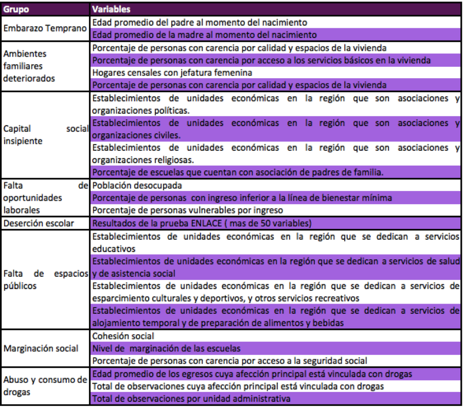

## Embarazo temprano

[figure not shown]

## Marginación y exclusión social

[figure not shown]

## Falta de oportunidades laborales, informalidad y desocupación

[figure not shown]

## Espacios públicos insuficientes y deteriorados

[figure not shown]

## Capital social y participación incipiente

[figure not shown]

## Deserción escolar

[figure not shown]

## Consumo y abuso de drogas legales e ilegales

[figure not shown]

## Ambientes familiares deteriorados y problemáticos

[figure not shown]

#### Embarazo Temprano

#### Ambiente Familiar Deteriorado

#### Capital Social Incipiente

#### Falta de Oportunidades Laborales

#### Deserción Escolar

#### Falta de Espacios Públicos

#### Marginación Social

#### Abuso y Consumo de Drogas

# Modelo

Siguiendo las recomendaciones del Dr. Vilalta se decidió utilizar tres variables dependientes 1. Delitos = sumatoria de todos los delitos ajustada por 100mil habitantes 2. Robo vehicular ajustado por 100 mil habitantes 3. Homicidios ajustados por 100 mil habitantes

Para las covariables se eligieron los componentes principales 1 y 2 para los 8 grupos de factores de riesgo descritos anteriormente. Los PCA de los factores consumo y abuso de drogas, embarazo temprano y espacios públicos deteriorados fueron retirados del modelo debido a la baja calidad de los datos reflejada en el nivel de outliers que contenían. En su lugar se utilizaron los Kmeans obtenidos en el análisis de componentes principales.